# Thusa

- Show All Code
- Hide All Code
- View Source

College-Age Renter Affordability: Early Data Exploration

## 1. Overview & Research Questions

This notebook explores housing affordability for college-age renters using American Community Survey (ACS) data accessed via `tidycensus`. We examine three core questions:

1. **Which U.S. states are most and least affordable for college-age renters (18–24), and how does this compare to older age groups?**
2. **What is the rent-to-income burden ratio for 18–24 year-olds by state, and how many states fall into “affordable” (<30%), “burdened” (30–50%), or “severely burdened” (>50%) categories?**
3. **How has the affordability gap between younger renters (18–24) and established adults (35–44) changed over recent years, and which states show the most significant generational disparities in housing costs?**

### Data Sources & Important Caveats

- **ACS Table B19049**: Median household income by age of householder.
- **ACS Table B25064**: Median gross rent (dollars).
- **Age Proxies**: ACS uses brackets 15–24, 25–44, 45–64, and 65+. We use **15–24** as the closest available proxy for the college-age (18–24) cohort and **25–44** as the proxy for established adults (35–44).
- **Householder vs. Individual**: These tables report income for the *householder* (the person who owns or rents the home). College students living in dorms or with parents are typically not householders and are therefore not captured in these household-level estimates. This is a standard limitation of Census household data for college-age affordability research.

## 2. Setup & Configuration

```r
library(tidycensus)
library(tidyverse)
library(scales)

# Create output folder for saved figures
dir.create("figures", showWarnings = FALSE)

# Census API Key

census_api_key("d6ea3b74acd33e1a166357b8af8134055725a821", install = TRUE, overwrite = TRUE)
```

```
[1] "d6ea3b74acd33e1a166357b8af8134055725a821"
```

```r
# Analysis Parameters
YEARS       <- 2010:2023                   # Years to analyze
SURVEY      <- "acs5"                      # "acs1" (1-year) or "acs5" (5-year)
STATE_FIPS  <- NULL                        # NULL = all states + DC

# HUD affordability thresholds
THRESH_AFFORDABLE <- 30
THRESH_BURDENED   <- 50
```

## 3. Data Ingestion

We pull state-level ACS estimates for median household income by age of householder (B19049) and median gross rent (B25064).

```r
# B19049: Median Household Income by Age of Householder
income_vars <- c(
  medinc_total   = "B19049_001",  # All ages
  medinc_15_24   = "B19049_002",  # Householder 15 to 24 years
  medinc_25_44   = "B19049_003",  # Householder 25 to 44 years
  medinc_45_64   = "B19049_004",  # Householder 45 to 64 years
  medinc_65_plus = "B19049_005"   # Householder 65 years and over
)

# B25064: Median Gross Rent (monthly dollars)
rent_vars <- c(med_rent = "B25064_001")

# head(income_vars)
```

```r
pull_state_data <- function(year, survey = "acs5") {

  message("Pulling data for ", year, " ...")

  # Income data (wide format)
  income_df <- get_acs(
    geography = "state",
    variables = income_vars,
    year = year,
    survey = survey,
    output = "wide",
    state = STATE_FIPS
  ) %>%
    mutate(year = year)

  # Rent data — same fix applied
  rent_df <- get_acs(
    geography = "state",
    variables = rent_vars,
    year = year,
    survey = survey,
    output = "wide",
    state = STATE_FIPS
  ) %>%
    mutate(year = year)

  # Merge
  full_df <- income_df %>%
    left_join(rent_df, by = c("GEOID", "NAME", "year"))

  return(full_df)
}

# Pull all years and combine
raw_data <- map_dfr(YEARS, ~ pull_state_data(.x, SURVEY))
```

```
Pulling data for 2010 ...
```

```
Pulling data for 2011 ...
```

```
Pulling data for 2012 ...
```

```
Pulling data for 2013 ...
```

```
Pulling data for 2014 ...
```

```
Pulling data for 2015 ...
```

```
Pulling data for 2016 ...
```

```
Pulling data for 2017 ...
```

```
Pulling data for 2018 ...
```

```
Pulling data for 2019 ...
```

```
Pulling data for 2020 ...
```

```
Pulling data for 2021 ...
```

```
Pulling data for 2022 ...
```

```
Pulling data for 2023 ...
```

```r
#names(raw_data)
```

```r
# Inspect structure
glimpse(raw_data)
```

```
Rows: 728
Columns: 15
$ GEOID           <chr> "01", "02", "04", "05", "06", "08", "09", "10", "11", …
$ NAME            <chr> "Alabama", "Alaska", "Arizona", "Arkansas", "Californi…
$ medinc_totalE   <dbl> 42081, 66521, 50448, 39267, 60883, 56456, 67740, 57599…
$ medinc_totalM   <dbl> 183, 642, 217, 283, 150, 309, 381, 651, 982, 173, 240,…
$ medinc_15_24E   <dbl> 21086, 40863, 28751, 21820, 32470, 28167, 31483, 32422…
$ medinc_15_24M   <dbl> 563, 1443, 765, 616, 415, 837, 1110, 1706, 1636, 407, …
$ medinc_25_44E   <dbl> 47474, 67966, 54942, 44551, 64374, 60717, 73744, 62038…
$ medinc_25_44M   <dbl> 492, 1193, 477, 648, 306, 498, 797, 864, 1525, 346, 34…
$ medinc_45_64E   <dbl> 51270, 78610, 60747, 47141, 73646, 69405, 84875, 70813…
$ medinc_45_64M   <dbl> 415, 1226, 408, 462, 296, 563, 675, 1192, 1520, 322, 4…
$ medinc_65_plusE <dbl> 29466, 45414, 37268, 28155, 40098, 37745, 39360, 39340…
$ medinc_65_plusM <dbl> 264, 1589, 338, 358, 206, 429, 532, 857, 1253, 181, 25…
$ year            <int> 2010, 2010, 2010, 2010, 2010, 2010, 2010, 2010, 2010, …
$ med_rentE       <dbl> 644, 972, 856, 617, 1147, 852, 982, 938, 1063, 957, 80…
$ med_rentM       <dbl> 4, 9, 4, 4, 2, 4, 5, 8, 13, 2, 3, 18, 5, 3, 3, 3, 4, 3…
```

```r
# Check column names
print(names(raw_data))
```

```
 [1] "GEOID"           "NAME"            "medinc_totalE"   "medinc_totalM"
 [5] "medinc_15_24E"   "medinc_15_24M"   "medinc_25_44E"   "medinc_25_44M"
 [9] "medinc_45_64E"   "medinc_45_64M"   "medinc_65_plusE" "medinc_65_plusM"
[13] "year"            "med_rentE"       "med_rentM"
```

```r
# Clean and standardize
clean_data <- raw_data %>%
  rename(state = NAME) %>%
  mutate(
    across(
      c(med_rentE, starts_with("medinc")),
      as.numeric
    )
  )

# Check missing values
missing_summary <- clean_data %>%
  summarise(
    across(
      c(med_rentE, starts_with("medinc")),
      ~ sum(is.na(.))
    )
  )

print(missing_summary)
```

```
# A tibble: 1 × 11
  med_rentE medinc_totalE medinc_totalM medinc_15_24E medinc_15_24M
      <int>         <int>         <int>         <int>         <int>
1         0             0             0             0             0
# ℹ 6 more variables: medinc_25_44E <int>, medinc_25_44M <int>,
#   medinc_45_64E <int>, medinc_45_64M <int>, medinc_65_plusE <int>,
#   medinc_65_plusM <int>
```

```r
# Filter out problematic rows
clean_data <- clean_data %>%
  filter(
    !is.na(med_rentE),
    !is.na(medinc_15_24E),
    medinc_15_24E > 0
  )

# Final sanity check
clean_data %>%
  select(state, year, med_rentE, medinc_15_24E) %>%
  head(10)
```

```
# A tibble: 10 × 4
   state                 year med_rentE medinc_15_24E
   <chr>                <int>     <dbl>         <dbl>
 1 Alabama               2010       644         21086
 2 Alaska                2010       972         40863
 3 Arizona               2010       856         28751
 4 Arkansas              2010       617         21820
 5 California            2010      1147         32470
 6 Colorado              2010       852         28167
 7 Connecticut           2010       982         31483
 8 Delaware              2010       938         32422
 9 District of Columbia  2010      1063         31006
10 Florida               2010       957         27317
```

## 4. Calculate Burden Metrics

We annualize rent (ACS reports monthly rent; income is annual), compute rent-to-income ratios for each age bracket, assign HUD burden categories, and calculate the generational affordability gap.

```r
analysis_df <- clean_data %>%
  mutate(
    # Annualize rent
    annual_rent = med_rentE * 12,

    # Rent-to-income ratios (%)
    rtb_15_24 = (annual_rent / medinc_15_24E) * 100,
    rtb_25_44 = (annual_rent / medinc_25_44E) * 100,

    # Affordability categories (young renters)
    burden_cat_young = case_when(
      rtb_15_24 < THRESH_AFFORDABLE ~ "Affordable (<30%)",
      rtb_15_24 <= THRESH_BURDENED  ~ "Burdened (30-50%)",
      TRUE                          ~ "Severely Burdened (>50%)"
    ) %>% factor(levels = c(
      "Affordable (<30%)",
      "Burdened (30-50%)",
      "Severely Burdened (>50%)"
    )),

    # Affordability categories (older group)
    burden_cat_established = case_when(
      rtb_25_44 < THRESH_AFFORDABLE ~ "Affordable (<30%)",
      rtb_25_44 <= THRESH_BURDENED  ~ "Burdened (30-50%)",
      TRUE                          ~ "Severely Burdened (>50%)"
    ) %>% factor(levels = c(
      "Affordable (<30%)",
      "Burdened (30-50%)",
      "Severely Burdened (>50%)"
    )),

    # Generational gap
    affordability_gap = rtb_15_24 - rtb_25_44
  )

# Quick Check
analysis_df %>%
  select(state, year, rtb_15_24, rtb_25_44) %>%
  head(10)
```

```
# A tibble: 10 × 4
   state                 year rtb_15_24 rtb_25_44
   <chr>                <int>     <dbl>     <dbl>
 1 Alabama               2010      36.6      16.3
 2 Alaska                2010      28.5      17.2
 3 Arizona               2010      35.7      18.7
 4 Arkansas              2010      33.9      16.6
 5 California            2010      42.4      21.4
 6 Colorado              2010      36.3      16.8
 7 Connecticut           2010      37.4      16.0
 8 Delaware              2010      34.7      18.1
 9 District of Columbia  2010      41.1      18.2
10 Florida               2010      42.0      21.8
```

## 5. Q1: Most & Least Affordable States for Young Renters

We rank states by the rent-to-income burden for the 15–24 age bracket (our proxy for 18–24) using the most recent year of data.

```r
latest_year <- max(analysis_df$year)

q1_rankings <- analysis_df %>%
  filter(year == latest_year) %>%
  select(
    state,
    rtb_15_24,
    rtb_25_44,
    affordability_gap,
    med_rentE
  ) %>%
  arrange(rtb_15_24)
```

### Most Affordable (Lowest Burden)

```r
head(q1_rankings, 10)
```

```
# A tibble: 10 × 5
   state         rtb_15_24 rtb_25_44 affordability_gap med_rentE
   <chr>             <dbl>     <dbl>             <dbl>     <dbl>
 1 Iowa               25.4      13.6              11.8       949
 2 Maine              26.0      15.1              10.8      1084
 3 South Dakota       26.3      13.4              12.8       912
 4 North Dakota       26.3      12.9              13.4       934
 5 New Hampshire      27.6      15.7              11.8      1423
 6 Idaho              28.7      16.7              12.0      1150
 7 Wisconsin          28.9      14.5              14.4      1045
 8 Minnesota          28.9      14.7              14.2      1235
 9 Arkansas           29.1      16.4              12.8       914
10 Ohio               29.2      15.1              14.1       988
```

### Least Affordable (Highest Burden)

```r
tail(q1_rankings, 10)
```

```
# A tibble: 10 × 5
   state                rtb_15_24 rtb_25_44 affordability_gap med_rentE
   <chr>                    <dbl>     <dbl>             <dbl>     <dbl>
 1 Oregon                    38.9      18.9              19.9      1450
 2 Maryland                  38.9      18.8              20.1      1662
 3 Texas                     39.1      19.5              19.6      1339
 4 Colorado                  40.3      20.0              20.3      1693
 5 New York                  40.4      19.4              21.0      1576
 6 Hawaii                    40.7      23.0              17.8      1938
 7 Florida                   42.2      23.9              18.4      1564
 8 District of Columbia      42.6      18.6              24.0      1900
 9 California                45.9      22.3              23.6      1956
10 Puerto Rico               60.5      23.4              37.1       562
```

## 6. Q2: Burden Categories for 18–24 Year-Olds

We classify each state into HUD affordability categories based on the young renter burden ratio and tally the results.

### Summary Counts

```r
q2_summary <- analysis_df %>%
  filter(year == latest_year) %>%
  count(burden_cat_young, name = "num_states") %>%
  mutate(pct_states = round((num_states / sum(num_states)) * 100, 1))

q2_summary
```

```
# A tibble: 3 × 3
  burden_cat_young         num_states pct_states
  <fct>                         <int>      <dbl>
1 Affordable (<30%)                13       25
2 Burdened (30-50%)                38       73.1
3 Severely Burdened (>50%)          1        1.9
```

### States by Category

```r
q2_by_state <- analysis_df %>%
  filter(year == latest_year) %>%
  select(state, rtb_15_24, burden_cat_young) %>%
  arrange(burden_cat_young, desc(rtb_15_24))

q2_by_state
```

```
# A tibble: 52 × 3
   state         rtb_15_24 burden_cat_young
   <chr>             <dbl> <fct>
 1 Kentucky           29.7 Affordable (<30%)
 2 Nebraska           29.5 Affordable (<30%)
 3 Wyoming            29.5 Affordable (<30%)
 4 Ohio               29.2 Affordable (<30%)
 5 Arkansas           29.1 Affordable (<30%)
 6 Minnesota          28.9 Affordable (<30%)
 7 Wisconsin          28.9 Affordable (<30%)
 8 Idaho              28.7 Affordable (<30%)
 9 New Hampshire      27.6 Affordable (<30%)
10 North Dakota       26.3 Affordable (<30%)
# ℹ 42 more rows
```

## 7. Q3: Trends & Generational Disparities

If multiple years are selected, we examine how the national affordability gap has evolved and identify states with the largest disparities.

### National Gap Trend

```r
gap_trend <- analysis_df %>%
  group_by(year) %>%
  summarise(
    mean_gap   = mean(affordability_gap, na.rm = TRUE),
    median_gap = median(affordability_gap, na.rm = TRUE),
    max_gap    = max(affordability_gap, na.rm = TRUE),
    min_gap    = min(affordability_gap, na.rm = TRUE),
    .groups = "drop"
  )

gap_trend
```

```
# A tibble: 14 × 5
    year mean_gap median_gap max_gap min_gap
   <int>    <dbl>      <dbl>   <dbl>   <dbl>
 1  2010     19.1       18.6    55.6    11.0
 2  2011     20.1       19.2    56.3    11.0
 3  2012     21.0       20.8    58.4    11.6
 4  2013     21.9       21.6    55.8    13.1
 5  2014     22.0       21.7    56.0    13.6
 6  2015     21.7       20.7    56.1    13.3
 7  2016     21.1       19.9    54.8    12.5
 8  2017     20.5       19.5    55.9    11.9
 9  2018     19.7       18.8    60.0    12.7
10  2019     19.2       18.2    61.4    12.1
11  2020     18.4       17.4    55.2    12.1
12  2021     18.1       17.5    52.6    11.8
13  2022     17.4       16.6    43.8    10.7
14  2023     16.9       15.9    37.1    10.8
```

### States with Largest Generational Gaps (Most Recent Year)

```r
largest_gaps <- analysis_df %>%
  filter(year == latest_year) %>%
  arrange(desc(affordability_gap)) %>%
  select(
    state = state,
    affordability_gap,
    rtb_15_24,
    rtb_25_44,
    med_rentE
  ) %>%
  head(10)

largest_gaps
```

```
# A tibble: 10 × 5
   state                affordability_gap rtb_15_24 rtb_25_44 med_rentE
   <chr>                            <dbl>     <dbl>     <dbl>     <dbl>
 1 Puerto Rico                       37.1      60.5      23.4       562
 2 District of Columbia              24.0      42.6      18.6      1900
 3 California                        23.6      45.9      22.3      1956
 4 New York                          21.0      40.4      19.4      1576
 5 Colorado                          20.3      40.3      20.0      1693
 6 Virginia                          20.3      38.7      18.4      1514
 7 Maryland                          20.1      38.9      18.8      1662
 8 Delaware                          20.1      38.2      18.1      1341
 9 Oregon                            19.9      38.9      18.9      1450
10 Louisiana                         19.9      37.7      17.8      1038
```

### States Where the Gap Has Widened Most

```r
gap_change <- analysis_df %>%
  select(year, state = state, affordability_gap) %>%
  filter(year %in% c(min(YEARS), max(YEARS))) %>%
  pivot_wider(
    names_from = year,
    values_from = affordability_gap,
    names_prefix = "yr_"
  ) %>%
  mutate(
    gap_change = !!sym(paste0("yr_", max(YEARS))) - !!sym(paste0("yr_", min(YEARS)))
  ) %>%
  arrange(desc(gap_change))

head(gap_change, 10)
```

```
# A tibble: 10 × 4
   state                yr_2010 yr_2023 gap_change
   <chr>                  <dbl>   <dbl>      <dbl>
 1 Wyoming                 11.0    16.1      5.11
 2 Delaware                16.6    20.1      3.50
 3 California              21.0    23.6      2.54
 4 Alaska                  11.4    13.1      1.75
 5 Maryland                18.3    20.1      1.75
 6 Utah                    12.9    14.5      1.63
 7 Virginia                19.1    20.3      1.23
 8 District of Columbia    22.9    24.0      1.07
 9 Vermont                 16.6    17.5      0.895
10 New Mexico              16.5    17.4      0.880
```

## 8. Visualizations

### Burden by State (Ranked Bar Chart)

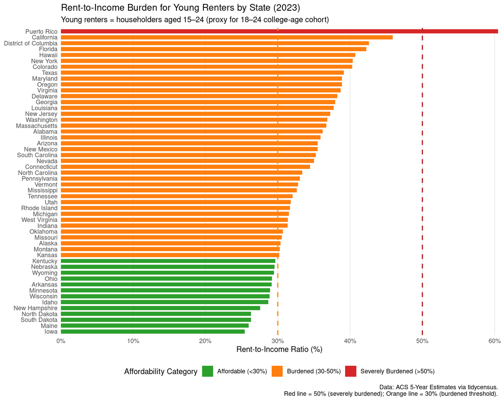

Figure 2.1: Rent-to-income burden for young renters (15–24) by state. Dashed lines show the 30% and 50% HUD thresholds.

```r
p1 <- analysis_df %>%
  filter(year == latest_year) %>%
  mutate(state = fct_reorder(state, rtb_15_24)) %>%
  ggplot(aes(x = rtb_15_24, y = state, fill = burden_cat_young)) +
  geom_col(width = 0.7) +
  geom_vline(
    xintercept = THRESH_AFFORDABLE,
    linetype = "dashed",
    color = "darkorange",
    linewidth = 0.8
  ) +
  geom_vline(
    xintercept = THRESH_BURDENED,
    linetype = "dashed",
    color = "firebrick",
    linewidth = 0.8
  ) +
  scale_fill_manual(values = c(
    "Affordable (<30%)"        = "#2ca02c",
    "Burdened (30-50%)"        = "#ff7f0e",
    "Severely Burdened (>50%)" = "#d62728"
  )) +
  scale_x_continuous(
    labels = percent_format(scale = 1),
    expand = c(0, 0)
  ) +
  labs(
    title    = paste(
      "Rent-to-Income Burden for Young Renters by State (",
      latest_year,
      ")",
      sep = ""
    ),
    subtitle = "Young renters = householders aged 15–24 (proxy for 18–24 college-age cohort)",
    x        = "Rent-to-Income Ratio (%)",
    y        = NULL,
    fill     = "Affordability Category",
    caption  = paste(
      "Data: ACS",
      ifelse(SURVEY == "acs1", "1-Year", "5-Year"),
      "Estimates via tidycensus.\nRed line = 50% (severely burdened); Orange line = 30% (burdened threshold)."
    )
  ) +
  theme_minimal(base_size = 11) +
  theme(
    legend.position      = "bottom",
    panel.grid.major.y   = element_blank(),
    panel.grid.minor     = element_blank()
  )

p1
```

### Young vs. Established Adults: Scatter Comparison

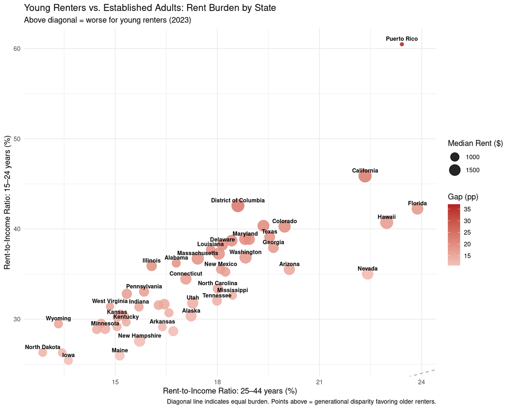

Figure 2.2: Comparison of rent burden between young renters (15–24) and established adults (25–44). Points above the diagonal indicate worse affordability for younger renters.

```r
p2 <- analysis_df %>%
  filter(year == latest_year) %>%
  ggplot(aes(x = rtb_25_44, y = rtb_15_24)) +
  geom_abline(
    slope = 1,
    intercept = 0,
    linetype = "dashed",
    color = "gray60"
  ) +
  geom_point(
    aes(size = med_rentE, color = affordability_gap),
    alpha = 0.85
  ) +
  geom_text(
    aes(label = state),
    check_overlap = TRUE,
    size = 2.8,
    vjust = -0.8,
    fontface = "bold"
  ) +
  scale_color_gradient2(
    low      = "steelblue",
    mid      = "white",
    high     = "firebrick",
    midpoint = 0,
    name     = "Gap (pp)"
  ) +
  scale_size_continuous(
    range = c(2, 8),
    name = "Median Rent ($)"
  ) +
  labs(
    title    = "Young Renters vs. Established Adults: Rent Burden by State",
    subtitle = paste(
      "Above diagonal = worse for young renters (",
      latest_year,
      ")",
      sep = ""
    ),
    x        = "Rent-to-Income Ratio: 25–44 years (%)",
    y        = "Rent-to-Income Ratio: 15–24 years (%)",
    caption  = "Diagonal line indicates equal burden. Points above = generational disparity favoring older renters."
  ) +
  theme_minimal(base_size = 11) +
  theme(legend.position = "right")

p2
```

### National Gap Trend Over Time

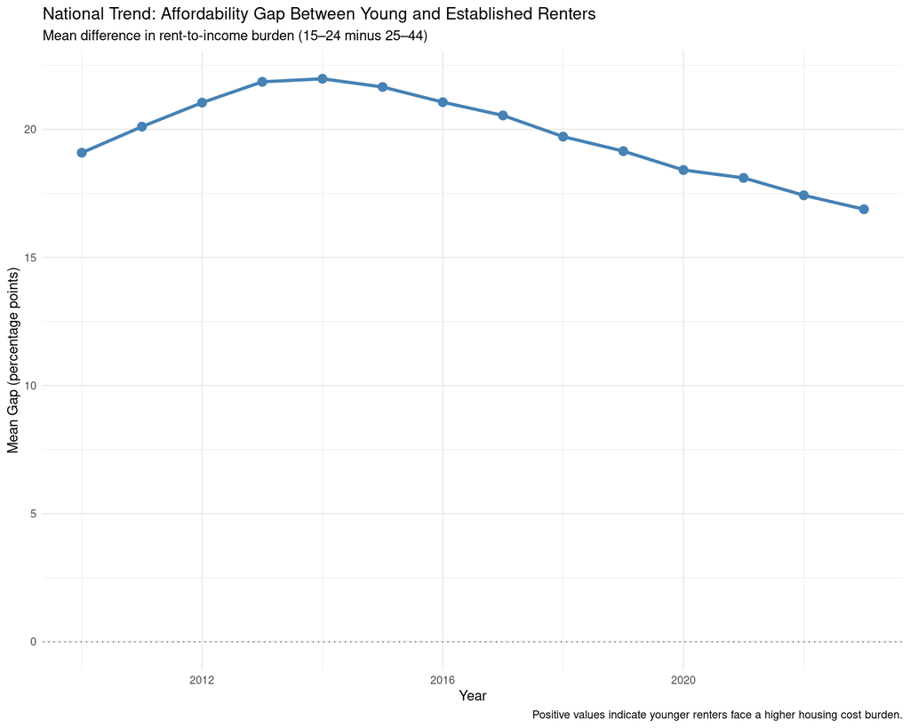

Figure 2.3: National trend in the mean affordability gap between young and established renters.

```r
p3 <- gap_trend %>%
  ggplot(aes(x = year, y = mean_gap)) +
  geom_line(color = "steelblue", linewidth = 1.2) +
  geom_point(size = 3, color = "steelblue") +
  geom_hline(yintercept = 0, linetype = "dotted", color = "gray50") +
  labs(
    title    = "National Trend: Affordability Gap Between Young and Established Renters",
    subtitle = "Mean difference in rent-to-income burden (15–24 minus 25–44)",
    x        = "Year",
    y        = "Mean Gap (percentage points)",
    caption  = "Positive values indicate younger renters face a higher housing cost burden."
  ) +
  theme_minimal(base_size = 11)

p3
```

## 9. Export Results

```r
write_csv(analysis_df, "state_rent_burden_analysis.csv")
ggsave("burden_by_state.png", p1, width = 10, height = 12, dpi = 300)
ggsave("young_vs_established_scatter.png", p2, width = 10, height = 8, dpi = 300)
if (exists("p3")) ggsave("gap_trend.png", p3, width = 10, height = 6, dpi = 300)
```